# Amritpal Singh (0851779)

**Table of Contents**

1. Installing Required Packages
2. General Understanding
3. Importings
4. Quick Information of data
5. EDA
6. Scaling
7. Optimal Clusters
   - Elbow Method
   - Silhouette Scores
   - Visualization - Clusters
8. Training - k means clustering
9. Clusters - Prediction
10. Marketing Strategies - Predictive Analysis
    - Cluster 0 (Mid-Range Listings with Moderate Popularity)
    - Cluster 1 (Higher-Priced, High-Availability Listings_)
    - Cluster 2 (Budget-Friendly Listings with Active Hosts)
    - Cluster 3 (Economical, Highly Available Listings)
11. Visualizations
12. References

# General understanding of data/files

# Installing Packages

```python
!pip install -r requirements.txt
```

# Importing Libraries

```python
# Importing Libraries

import os
import joblib
import warnings
import pandas as pd
import seaborn as sns
import matplotlib.pyplot as plt
from sklearn.cluster import KMeans
import matplotlib.ticker as ticker
from matplotlib.patches import Patch
from sklearn.decomposition import PCA
from sklearn.metrics import silhouette_score
from sklearn.preprocessing import MinMaxScaler


# Suppressing all the warnings
warnings.filterwarnings('ignore')
```

```python
# Storing all the data files in a list

data_files = ['calendar', 'listings', 'listings2', 'reviews']
```

# Data Quick Information

```python
# Running a quick analysis over the shape and columns of all of our datasets

for file in data_files:
    print("File:-", file)
    df = pd.read_csv(f'Data-AirBNB//{file}.csv', dtype = str)
    rows, columns = df.shape
    print("Rows:-", rows)
    print("Columns:-", columns)
    print(', '.join(df.columns))
    print()
```

```
File:- calendar
Rows:- 7966127
Columns:- 7
listing_id, date, available, price, adjusted_price, minimum_nights, maximum_nights

File:- listings
Rows:- 21825
Columns:- 75
id, listing_url, scrape_id, last_scraped, source, name, description, neighborhood_overview, picture_url, host_id, host_url, host_name, host_since, host_location, host_about, host_response_time, host_response_rate, host_acceptance_rate, host_is_superhost, host_thumbnail_url, host_picture_url, host_ne…

File:- listings2
Rows:- 21825
Columns:- 18
id, name, host_id, host_name, neighbourhood_group, neighbourhood, latitude, longitude, room_type, price, minimum_nights, number_of_reviews, last_review, reviews_per_month, calculated_host_listings_count, availability_365, number_of_reviews_ltm, license

File:- reviews
Rows:- 571853
Columns:- 6
listing_id, id, date, reviewer_id, reviewer_name, comments
```

### **calendar file:**

1. **listing_id**: Unique identifier for each listing.
2. **date**: Date for the listing's availability.
3. **available**: Whether the listing is available on that date (true/false).
4. **price**: Price of the listing per night.
5. **adjusted_price**: Price adjusted based on discounts or surcharges.
6. **minimum_nights**: Minimum number of nights a guest can book.
7. **maximum_nights**: Maximum number of nights a guest can book.

### **listings file:**

1. **id**: Unique identifier for the listing.
2. **listing_url**: URL to the listing on Airbnb.
3. **scrape_id**: Identifier for the data scrape session.
4. **last_scraped**: Date when the listing was last scraped.
5. **source**: Source of the listing data (typically Airbnb).
6. **name**: Name/title of the listing.
7. **description**: Detailed description of the listing.
8. **neighborhood_overview**: Overview of the neighborhood where the listing is located.
9. **picture_url**: URL of the listing's main image.
10. **host_id**: Unique identifier for the host.
11. **host_url**: URL to the host's profile on Airbnb.
12. **host_name**: Name of the host.
13. **host_since**: Date when the host joined Airbnb.
14. **host_location**: Location of the host.
15. **host_about**: Personal description written by the host.
16. **host_response_time**: How quickly the host typically responds.
17. **host_response_rate**: Host's response rate as a percentage.
18. **host_acceptance_rate**: Host's acceptance rate for booking requests.
19. **host_is_superhost**: Indicates if the host is a "Superhost" (true/false).
20. **host_thumbnail_url**: URL to the host's thumbnail image.
21. **host_picture_url**: URL to the host's main image.
22. **host_neighbourhood**: Neighbourhood where the host resides.
23. **host_listings_count**: Number of listings the host manages.
24. **host_total_listings_count**: Total number of listings associated with the host.
25. **host_verifications**: Verification methods completed by the host.
26. **host_has_profile_pic**: Indicates if the host has a profile picture (true/false).
27. **host_identity_verified**: Indicates if the host's identity is verified (true/false).
28. **neighbourhood**: Neighbourhood where the listing is located.
29. **neighbourhood_cleansed**: Standardized neighborhood name.
30. **neighbourhood_group_cleansed**: Larger grouping of neighborhoods (if available).
31. **latitude**: Latitude coordinate of the listing.
32. **longitude**: Longitude coordinate of the listing.
33. **property_type**: Type of property (e.g., apartment, house).
34. **room_type**: Type of room offered (e.g., entire place, private room).
35. **accommodates**: Number of guests the listing can accommodate.
36. **bathrooms**: Number of bathrooms.
37. **bathrooms_text**: Descriptive text about the bathroom setup.
38. **bedrooms**: Number of bedrooms.
39. **beds**: Number of beds.
40. **amenities**: List of amenities provided.
41. **price**: Price of the listing per night.
42. **minimum_nights**: Minimum number of nights required for booking.
43. **maximum_nights**: Maximum number of nights allowed for booking.
44. **minimum_minimum_nights**: Shortest minimum night requirement across booking windows.
45. **maximum_minimum_nights**: Longest minimum night requirement across booking windows.
46. **minimum_maximum_nights**: Shortest maximum night limit across booking windows.
47. **maximum_maximum_nights**: Longest maximum night limit across booking windows.
48. **minimum_nights_avg_ntm**: Average minimum nights required for future bookings.
49. **maximum_nights_avg_ntm**: Average maximum nights allowed for future bookings.
50. **calendar_updated**: How recently the calendar was updated.
51. **has_availability**: Indicates if the listing has availability (true/false).
52. **availability_30**: Number of available nights in the next 30 days.
53. **availability_60**: Number of available nights in the next 60 days.
54. **availability_90**: Number of available nights in the next 90 days.
55. **availability_365**: Number of available nights in the next 365 days.
56. **calendar_last_scraped**: Date when the calendar was last scraped.
57. **number_of_reviews**: Total number of reviews for the listing.
58. **number_of_reviews_ltm**: Number of reviews in the last 12 months.
59. **number_of_reviews_l30d**: Number of reviews in the last 30 days.
60. **first_review**: Date of the first review for the listing.
61. **last_review**: Date of the most recent review.
62. **review_scores_rating**: Overall rating score based on guest reviews.
63. **review_scores_accuracy**: Accuracy rating based on guest reviews.
64. **review_scores_cleanliness**: Cleanliness rating based on guest reviews.
65. **review_scores_checkin**: Check-in process rating based on guest reviews.
66. **review_scores_communication**: Communication rating based on guest reviews.
67. **review_scores_location**: Location rating based on guest reviews.
68. **review_scores_value**: Value-for-money rating based on guest reviews.
69. **license**: License number for the listing (if applicable).
70. **instant_bookable**: Indicates if the listing is available for instant booking (true/false).
71. **calculated_host_listings_count**: Number of listings under the same host.
72. **calculated_host_listings_count_entire_homes**: Number of entire home listings by the host.
73. **calculated_host_listings_count_private_rooms**: Number of private room listings by the host.
74. **calculated_host_listings_count_shared_rooms**: Number of shared room listings by the host.
75. **reviews_per_month**: Average number of reviews the listing receives per month.

### **listings2 file:**

1. **id**: Unique identifier for the listing.
2. **name**: Name/title of the listing.
3. **host_id**: Unique identifier for the host.
4. **host_name**: Name of the host.
5. **neighbourhood_group**: Larger grouping of neighborhoods (if available).
6. **neighbourhood**: Neighbourhood where the listing is located.
7. **latitude**: Latitude coordinate of the listing.
8. **longitude**: Longitude coordinate of the listing.
9. **room_type**: Type of room offered (e.g., entire place, private room).
10. **price**: Price of the listing per night.
11. **minimum_nights**: Minimum number of nights required for booking.
12. **number_of_reviews**: Total number of reviews for the listing.
13. **last_review**: Date of the most recent review.
14. **reviews_per_month**: Average number of reviews the listing receives per month.
15. **calculated_host_listings_count**: Number of listings under the same host.
16. **availability_365**: Number of available nights in the next 365 days.
17. **number_of_reviews_ltm**: Number of reviews in the last 12 months.
18. **license**: License number for the listing (if applicable).

### **reviews file:**

1. **listing_id**: Unique identifier for the listing being reviewed.
2. **id**: Unique identifier for the review.
3. **date**: Date when the review was posted.
4. **reviewer_id**: Unique identifier for the reviewer.
5. **reviewer_name**: Name of the reviewer.
6. **comments**: Comments left by the reviewer.

# EDA

**We will be using the dataset `listings2` for Segmentation. We will run the EDA and the model according to segmentation problem.**

```python
# Reading listings2 dataset as this will be used for segmentation

df = pd.read_csv("Data-AirBNB//listings2.csv")
listings2 = df.copy()
listings2.head(5)
```

|  | id | name | host_id | host_name | neighbourhood_group | neighbourhood | latitude | longitude | room_type | price | minimum_nights | number_of_reviews | last_review | reviews_per_month | calculated_host_listings_count | availability_365 | number_of_reviews_ltm | license |
| --- | --- | --- | --- | --- | --- | --- | --- | --- | --- | --- | --- | --- | --- | --- | --- | --- | --- | --- |
| 0 | 533659 | Best View in Downtown 5 Star Luxury 1+1 w/office | 1019968 | Roman | NaN | Waterfront Communities-The Island | 43.63953 | -79.38257 | Entire home/apt | 324.0 | 10 | 188 | 8/21/2024 | 1.27 | 1 | 142 | 13 | STR-2011-FLKRVB |
| 1 | 537679 | NIce room with private bathroom | 2586974 | Yin | NaN | Mimico (includes Humber Bay Shores) | 43.62452 | -79.48793 | Private room | NaN | 28 | 0 | NaN | NaN | 1 | 0 | 0 | NaN |
| 2 | 543810 | Spacious 1+1 Condo Downtown Toronto | 2671905 | R. | NaN | Waterfront Communities-The Island | 43.63942 | -79.39216 | Entire home/apt | NaN | 28 | 10 | 8/16/2015 | 0.07 | 1 | 0 | 0 | NaN |
| 3 | 547777 | A Beautiful Funky Toronto Apartment | 2692759 | Ayelet And Sean | NaN | Palmerston-Little Italy | 43.66051 | -79.42741 | Entire home/apt | NaN | 28 | 2 | 8/5/2013 | 0.01 | 1 | 0 | 0 | NaN |
| 4 | 560148 | Cozy room, King Bed, Great Location | 1027776 | Willy | NaN | Mount Pleasant West | 43.69821 | -79.39164 | Private room | 65.0 | 30 | 39 | 9/15/2019 | 0.27 | 2 | 365 | 0 | NaN |

```python
# Shape of our dataset

listings2.shape
```

```
(21825, 18)
```

**Let's remove unwanted features from our dataset**

- id
- name
- host_id
- host_name
- neighbourhood_group
- neighbourhood
- last_review
- license

**The above features are obvious features which we are sure are not required according to their definition.**

```python
listings2.drop(columns = ['id', 'name', 'host_id', 'host_name', 'last_review', 'license', 'neighbourhood', 'neighbourhood_group'], inplace = True)
listings2.head(5)
```

|  | latitude | longitude | room_type | price | minimum_nights | number_of_reviews | reviews_per_month | calculated_host_listings_count | availability_365 | number_of_reviews_ltm |
| --- | --- | --- | --- | --- | --- | --- | --- | --- | --- | --- |
| 0 | 43.63953 | -79.38257 | Entire home/apt | 324.0 | 10 | 188 | 1.27 | 1 | 142 | 13 |
| 1 | 43.62452 | -79.48793 | Private room | NaN | 28 | 0 | NaN | 1 | 0 | 0 |
| 2 | 43.63942 | -79.39216 | Entire home/apt | NaN | 28 | 10 | 0.07 | 1 | 0 | 0 |
| 3 | 43.66051 | -79.42741 | Entire home/apt | NaN | 28 | 2 | 0.01 | 1 | 0 | 0 |
| 4 | 43.69821 | -79.39164 | Private room | 65.0 | 30 | 39 | 0.27 | 2 | 365 | 0 |

**So, we dropped some columns which held values like ids, names, redundant, etc. Now, we can move forward with further analysis from here**

**Let's start with dealing with the null values**

```python
# Checking any null value

listings2.isnull().sum()
```

```
latitude                             0
longitude                            0
room_type                            0
price                             5289
minimum_nights                       0
number_of_reviews                    0
reviews_per_month                 5215
calculated_host_listings_count       0
availability_365                     0
number_of_reviews_ltm                0
dtype: int64
```

```python
# Getting the percentage of null values

listings2.apply(lambda x: f"{round((x.isnull().sum() / len(listings2)) * 100)} %")
```

```
latitude                           0 %
longitude                          0 %
room_type                          0 %
price                             24 %
minimum_nights                     0 %
number_of_reviews                  0 %
reviews_per_month                 24 %
calculated_host_listings_count     0 %
availability_365                   0 %
number_of_reviews_ltm              0 %
dtype: object
```

- price (5289 - 24%)
- reviews_per_month (5215 - 24%)

**It is essential very essential for us to deal with null values. We can see that two columns having ~24% of data missing. it is too much data to delete or ignore. So, we should impute the data values for these two columns.** **Before choosing any imputation method let's check the distribution of both of these columns**

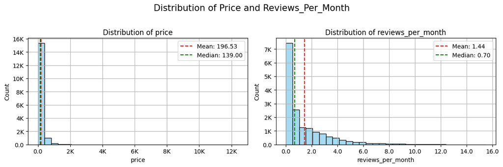

```python
# Visualizing the distribution of the above columns which to decide which imputation method we should use to fill in the missing values.

# Set up the plotting area for side-by-side plots
fig, axes = plt.subplots(1, 2, figsize = (12, 4))

# Setting the Title of the plots
fig.suptitle('Distribution of Price and Reviews_Per_Month', fontsize = 15)

for i, col in enumerate(['price', 'reviews_per_month']):
    mean_val = listings2[col].mean()
    median_val = listings2[col].median()

    # Visualization - Histogram
    sns.histplot(listings2[col], bins = 30, color = 'skyblue', ax = axes[i], stat = 'count')

    # Visualization - axline for mean & median
    axes[i].axvline(mean_val, color = 'red', linestyle = '--', label = f'Mean: {mean_val:.2f}')
    axes[i].axvline(median_val, color = 'green', linestyle = '--', label = f'Median: {median_val:.2f}')

    # Titles and Labels
    axes[i].set_title(f'Distribution of {col}')
    axes[i].set_xlabel(col)
    axes[i].set_ylabel('Count')
    axes[i].legend()
    axes[i].grid()

    # Formatting the x-axis & y-axis
    def format_ticks(value):
        if value >= 1_000_000:
            return f'{value / 1_000_000:.0f}M'
        elif value >= 1_000:
            return f'{value / 1_000:.0f}K'
        else:
            return str(value)

    # Setting the axis' values
    axes[i].xaxis.set_major_formatter(ticker.FuncFormatter(lambda x, _: format_ticks(x)))
    axes[i].yaxis.set_major_formatter(ticker.FuncFormatter(lambda y, _: format_ticks(y)))

plt.tight_layout(rect=[0, 0, 1, 0.96])
plt.show()
```

As per the above visualization, we can see that in both of the columns' distribution the mean is getting affected by the skewness of the data. We can confirm with this that we should use Median Imputation Method.  
Although, there are a lot of other imputation methods too but we will keep it simple for now.

```python
# Median Imputation

# getting the medians of both the columns
median_price = listings2['price'].median()
median_reviews_per_month = listings2['reviews_per_month'].median()

# Imputing the missing values with their respective medians
listings2['price'].fillna(median_price, inplace = True)
listings2['reviews_per_month'].fillna(median_reviews_per_month, inplace = True)

listings2.isnull().sum()
```

```
latitude                          0
longitude                         0
room_type                         0
price                             0
minimum_nights                    0
number_of_reviews                 0
reviews_per_month                 0
calculated_host_listings_count    0
availability_365                  0
number_of_reviews_ltm             0
dtype: int64
```

```python
# Information of the data

listings2.info()
```

```
<class 'pandas.core.frame.DataFrame'>
RangeIndex: 21825 entries, 0 to 21824
Data columns (total 10 columns):
 #   Column                          Non-Null Count  Dtype
---  ------                          --------------  -----
 0   latitude                        21825 non-null  float64
 1   longitude                       21825 non-null  float64
 2   room_type                       21825 non-null  object
 3   price                           21825 non-null  float64
 4   minimum_nights                  21825 non-null  int64
 5   number_of_reviews               21825 non-null  int64
 6   reviews_per_month               21825 non-null  float64
 7   calculated_host_listings_count  21825 non-null  int64
 8   availability_365                21825 non-null  int64
 9   number_of_reviews_ltm           21825 non-null  int64
dtypes: float64(4), int64(5), object(1)
memory usage: 1.7+ MB
```

```python
# Checking the unique values of the column with object type

listings2['room_type'].unique()
```

```
array(['Entire home/apt', 'Private room', 'Shared room'], dtype=object)
```

**as we can see, now we have dealt with all the unwanted columns and missing values. Now, we will encode the columns `room_type`**

```python
# Creating a mapping for column's unique values
room_type_mapping = {
    'Entire home/apt': 2,
    'Private room': 1,
    'Shared room': 0
}

# Applying the mappin over the column
listings2['room_type'] = listings2['room_type'].map(room_type_mapping)

listings2.head(5)
```

|  | latitude | longitude | room_type | price | minimum_nights | number_of_reviews | reviews_per_month | calculated_host_listings_count | availability_365 | number_of_reviews_ltm |
| --- | --- | --- | --- | --- | --- | --- | --- | --- | --- | --- |
| 0 | 43.63953 | -79.38257 | 2 | 324.0 | 10 | 188 | 1.27 | 1 | 142 | 13 |
| 1 | 43.62452 | -79.48793 | 1 | 139.0 | 28 | 0 | 0.70 | 1 | 0 | 0 |
| 2 | 43.63942 | -79.39216 | 2 | 139.0 | 28 | 10 | 0.07 | 1 | 0 | 0 |
| 3 | 43.66051 | -79.42741 | 2 | 139.0 | 28 | 2 | 0.01 | 1 | 0 | 0 |
| 4 | 43.69821 | -79.39164 | 1 | 65.0 | 30 | 39 | 0.27 | 2 | 365 | 0 |

**Before moving forward with any modeling steps, let's check all the unique values of the columns to find discrepancy if any.**

```python
for col in listings2.columns:
    print(col)
    print(listings2[col].unique())
    print()
```

```
latitude
[43.63953    43.62452    43.63942    ... 43.67552425 43.6584633
 43.64129161]

longitude
[-79.38257    -79.48793    -79.39216    ... -79.44212902 -79.3841276
 -79.39637268]

room_type
[2 1 0]

price
[3.240e+02 1.390e+02 6.500e+01 1.490e+02 1.190e+02 8.400e+01 4.500e+01
 1.500e+02 1.200e+02 1.900e+02 8.300e+01 9.500e+01 2.000e+02 1.800e+02
 5.000e+02 1.160e+02 1.450e+02 9.200e+01 4.440e+02 4.400e+02 2.710e+02
 2.780e+02 9.800e+01 8.800e+01 1.000e+03 8.700e+01 1.960e+02 4.750e+02
 4.700e+02 3.500e+02 7.500e+01 1.210e+02 1.600e+02 5.000e+01 6.000e+01
 9.900e+01 8.000e+01 1.300e+02 1.250e+02 1.150e+02 1.700e+02 2.750e+02
 1.000e+02 4.990e+02 3.300e+02 1.550e+02 1.720e+02 7.900e+01 1.260e+02
 1.480e+02 9.000e+01 1.630e+02 3.090e+02 6.600e+01 1.290e+02 2.500e+02
 2.950e+02 3.000e+02 3.220e+02 4.400e+01 2.800e+02 2.880e+02 3.610e+02
 3.000e+01 6.200e+01 6.900e+01 5.500e+01 2.790e+02 1.060e+02 1.100e+02
 1.080e+02 3.990e+02 9.700e+01 4.390e+02 7.800e+01 2.250e+02 2.550e+02
 2.220e+02 1.860e+02 7.700e+01 7.100e+01 1.350e+02 1.310e+02 2.180e+02
 1.090e+02 2.690e+02 1.750e+02 2.360e+02 2.650e+02 5.300e+01 1.460e+02
 5.900e+01 1.530e+02 8.600e+01 1.730e+02 8.100e+01 5.700e+01 7.600e+01
 3.260e+02 8.500e+01 3.020e+02 2.300e+02 1.050e+02 1.850e+02 3.490e+02
 1.430e+02 5.500e+02 6.400e+01 7.200e+01 1.660e+02 1.520e+02 1.400e+02
 2.140e+02 1.560e+02 1.010e+02 9.100e+01 1.680e+02 3.960e+02 9.300e+01
 1.870e+02 1.280e+02 2.200e+02 2.490e+02 4.490e+02 1.670e+02 2.160e+02
 1.620e+02 2.590e+02 1.570e+02 8.880e+02 2.460e+02 2.370e+02 5.980e+02
 1.110e+02 7.000e+01 2.240e+02 2.580e+02 3.380e+02 6.300e+01 8.520e+02
 3.130e+02 5.400e+01 2.640e+02 1.890e+02 1.340e+02 8.900e+01 6.100e+01
 2.680e+02 3.700e+02 9.400e+01 9.990e+02 3.640e+02 1.910e+02 1.380e+02
 1.790e+02 1.240e+02 6.700e+01 4.000e+02 1.980e+02 2.820e+02 4.890e+02
 1.370e+02 7.990e+02 2.540e+02 6.590e+02 9.600e+01 3.900e+01 6.900e+02
 3.410e+02 1.820e+02 1.120e+02 1.690e+02 6.800e+01 1.330e+02 1.410e+02
 2.400e+02 4.050e+02 8.950e+02 3.750e+02 2.290e+02 4.450e+02 1.640e+02
 3.350e+02 1.220e+02 2.660e+02 3.830e+02 4.200e+01 5.800e+01 9.000e+02
 1.230e+02 2.990e+02 3.070e+02 2.980e+02 1.020e+02 4.100e+01 2.730e+02
```

[output cut: 280 more lines]

```
 272 114 299 223 228 147 361 352 252 289  84 210 354 212 185   9 285 357
  37 172 302  22 150  52 156 148  25  86  73   3 103 256 261  38 282 104
 200 204 227 162 311 330  16 121 168   7 295  18 196  44 271  85   8 269
 360  58 250 283 211 288 254 292 197 130 276  96 101 203 153  78  76 163
 186 226  45 195  55  82 284 314 327 240 176 113 294 235 109 343 213 350
 194 202 126 297 192 209]

number_of_reviews_ltm
[ 13   0   4   1   2  22   5  70  18 115   6  27  48  19   3  10   7  30
 113  16  47  64  28  29  12  15  11  57  52  50  60   9  81   8  20  82
  44  49  56  21  14  33  43  34  35  39  53  17  23  24  26  45  38  40
  66  46  62  32  69  37  25  41  72  36  80  31  59  67  54  63  79  61
  89  42 109  73 140  71  55  51  98 116 101  96  75  58 126 136  77  85
  65  90  76  86  93 176 103 122 118  94  91 112  78  68  99 108  74 114
  92 106  84  83 100  97  88 110 123 129 117 142 120]
```

**Let's Give a check to the minimum and maximum values of the numerical features**

```python
for col in listings2.columns:
    print(col)
    print(listings2[col].min(), listings2[col].max())
    print()
```

```
latitude
43.58575 43.83774

longitude
-79.62395 -79.12622

room_type
0 2

price
3.0 12400.0

minimum_nights
1 1125

number_of_reviews
0 1116

reviews_per_month
0.01 15.48

calculated_host_listings_count
1 101

availability_365
0 365

number_of_reviews_ltm
0 176
```

**As we can see the `price` column particularly has minmum value of `$3` which is not correct because on researching, we found that the minimum price mentioned on AirBNB website is `$10` so, we will replace all the price values less than 10 with 10 as value below that does not hold much information.**

```python
listings2['price'] = listings2['price'].apply(lambda x: 10 if x < 10 else x)
```

```python
listings2['price'].min()
```

```
10.0
```

**Everything looks good so far. there are some values in the data which are far away from most of the values. It is possible these values are outliers but we cannot be sure about it & outliers can also be important. So, as for now we will mvoe forward with this data for the modeling.**

```python
model_data = listings2.copy()
```

# Scaling

```python
# SCALING

# Creating an instance of MinMaxScaler
min_max_scaler = MinMaxScaler()

# Looping over all the columns to scale them one-by-one
for col in list(model_data.columns):
    model_data[col] = min_max_scaler.fit_transform(model_data[[col]])

model_data.head(5)
```

|  | latitude | longitude | room_type | price | minimum_nights | number_of_reviews | reviews_per_month | calculated_host_listings_count | availability_365 | number_of_reviews_ltm |
| --- | --- | --- | --- | --- | --- | --- | --- | --- | --- | --- |
| 0 | 0.213421 | 0.484962 | 1.0 | 0.025343 | 0.008007 | 0.168459 | 0.081448 | 0.00 | 0.389041 | 0.073864 |
| 1 | 0.153855 | 0.273281 | 0.5 | 0.010412 | 0.024021 | 0.000000 | 0.044602 | 0.00 | 0.000000 | 0.000000 |
| 2 | 0.212985 | 0.465694 | 1.0 | 0.010412 | 0.024021 | 0.008961 | 0.003878 | 0.00 | 0.000000 | 0.000000 |
| 3 | 0.296678 | 0.394873 | 1.0 | 0.010412 | 0.024021 | 0.001792 | 0.000000 | 0.00 | 0.000000 | 0.000000 |
| 4 | 0.446288 | 0.466739 | 0.5 | 0.004439 | 0.025801 | 0.034946 | 0.016807 | 0.01 | 1.000000 | 0.000000 |

**We scaled the data as it is very imporant step for segmentation modeling. As in segmentation we use distance algorithms which will perform poorly if features are on different scales since they may give undue weight to features with larger ranges.**  
**We will use K-means clustering algorithm. Let's apply Elbow Method in order to get the optimal clusters (K) for our model.**

# Finding Optimal Clusters

### 1. Elbow Method

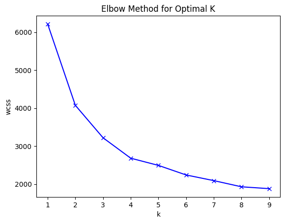

```python
# WCSS -  Within-Cluster Sum of Square

wcss = []
for k in range(1, 10):
    km = KMeans(n_clusters = k)
    km = km.fit(model_data)
    wcss.append(km.inertia_)

# Visualization - Line Plot
plt.plot(range(1, 10), wcss, 'bx-')

# Lableling
plt.xlabel('k')
plt.ylabel('wcss')
plt.title('Elbow Method for Optimal K')

# Showing the Plot
plt.show()
```

**Well, looking at the elbow method plot we can't really tell the optimal number of clusters. Although, we can still make an assumption & according to me, the optimal number of clusters should be `4`. After 4, the line is descending at slow pace.**  
**We got the optimal value But, to confirm if it is correct we can perform further analysis:**

- **`Silhouette Scores:`** This score measures how similar an object is to its own cluster compared to other clusters. Evaluating different k values using the Silhouette Score can provide additional confirmation of the optimal choice.
- **`Visual Inspection of Clusters:`** Plotting and inspecting the clustered data can offer qualitative insights into the clustering results, helping to validate the choice of k.

### 2. Silhouette Scores

```
For n_clusters = 2, the silhouette score is: 0.32501958450457896
For n_clusters = 3, the silhouette score is: 0.32276536576708276
For n_clusters = 4, the silhouette score is: 0.33399478819605516
For n_clusters = 5, the silhouette score is: 0.33235611400552506
For n_clusters = 6, the silhouette score is: 0.32298464172337815
For n_clusters = 7, the silhouette score is: 0.3228853047765068
For n_clusters = 8, the silhouette score is: 0.2877805878993414
For n_clusters = 9, the silhouette score is: 0.29937800387349905
```

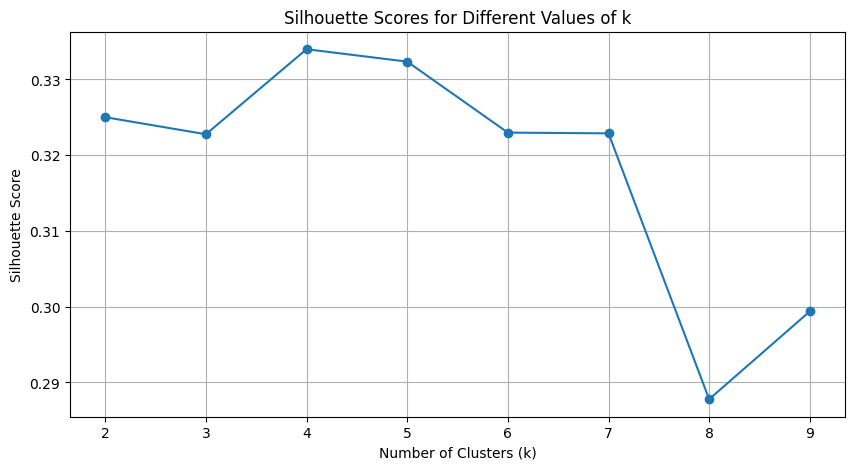

```python
# Silhouette Scores

silh_scores = []
for n_clusters in range(2, 10):
    # KMeans for different n_clusters
    kmeans = KMeans(n_clusters = n_clusters, random_state = 42)
    cluster_labels = kmeans.fit_predict(model_data)

    # Finding the Silhouette Scores
    silh_avg = silhouette_score(model_data, cluster_labels)
    silh_scores.append(silh_avg)
    print(f"For n_clusters = {n_clusters}, the silhouette score is: {silh_avg}")



# PLOTTING Silhouette Scores

# Setting plot/figure size
plt.figure(figsize = (10, 5))

# Visualization - Line Plot (Silhouette Scores)
plt.plot(range(2, 10), silh_scores, marker = 'o')

# Labeling
plt.title('Silhouette Scores for Different Values of k')
plt.xlabel('Number of Clusters (k)')
plt.ylabel('Silhouette Score')
plt.xticks(range(2, 10))

# For Gridlines
plt.grid()

# Showing the plot
plt.show()
```

**As we can see according to the `Silhouette Scores`, the optimal cluster is coming up as `4` as the score of 4 clusters is the highest. It means, our previous observation aligns with our new analysis. Still, let's solidify our analyses more by visually plotting the clusters.**

### 3. Visual Inspection of Clusters

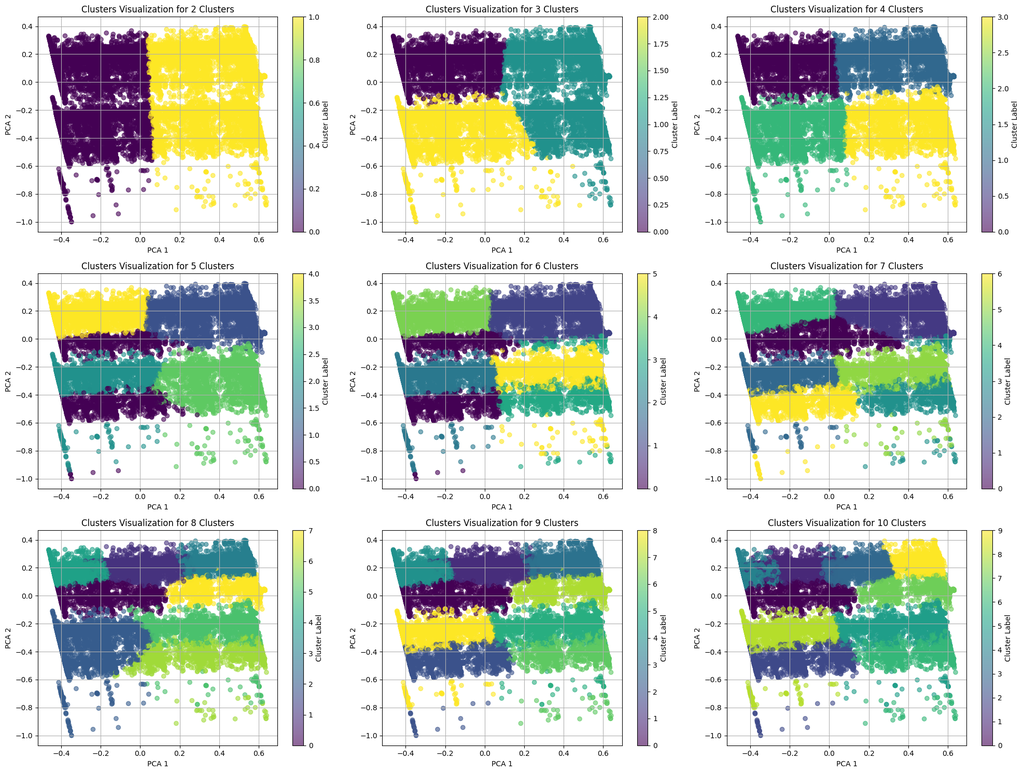

```python
# Setting up the plots
plt.figure(figsize = (20, 15))

for i, optimal_k in enumerate(range(2, 11)):
    # Using KMeans
    kmeans = KMeans(n_clusters = optimal_k, random_state = 42)
    cluster_labels = kmeans.fit_predict(model_data)

    # Reducing the dimensionality for visualization (PCA - Principal Component Analysis)
    pca = PCA(n_components = 2)
    reduced_features = pca.fit_transform(model_data)

    # Creating a DataFrame for plotting
    plot_data = pd.DataFrame(reduced_features, columns = ['PC1', 'PC2'])
    plot_data['Cluster'] = cluster_labels

    # Creating a subplot for each cluster count
    plt.subplot(3, 3, i + 1)

    # Visualization - Scatter Plot
    plt.scatter(plot_data['PC1'], plot_data['PC2'], c = plot_data['Cluster'], cmap = 'viridis', alpha = 0.6)

    # Labeling
    plt.title(f'Clusters Visualization for {optimal_k} Clusters')
    plt.xlabel('PCA 1')
    plt.ylabel('PCA 2')
    plt.colorbar(label = 'Cluster Label')

    # Gridlines
    plt.grid()

# Adjust layout
plt.tight_layout()

# Showing all plots
plt.show()
```

**In above clustering visualization, we visualized `9 plots` ranging from n_cluster = `2 - 10`. We can clearly see that the optimal value of k (n_clusters) is coming up as `4` her as well. We want to have as much cluster as we can get and the highest clean clusters we are getting is with optimal value of k as `4`. So, by doing 3 different analyses we can confirm now that the `otpimal value of k (n_clusters) = 4`**

# Training

### k-means Clustering Algorithm

```python
clustered_model = model_data.copy()


if os.path.exists('./Models/Clustering/km.pkl'):
    print('Model Exists. Loading the model')

    # Loading the model
    km_model = joblib.load('./Models/Clustering/km.pkl')
else:
    print('Model not Found. Creating & Saving the model')

    # Clustering using the KMeans algorithm
    km_model = KMeans(n_clusters = 4, random_state = 42)
    km_model.fit(clustered_model)

    # Saving the model
    joblib.dump(kmeans, './Models/Clustering/km.pkl')


# Getting the predictions
km_predictions = km_model.predict(clustered_model)
clustered_model['PredictedCluster'] = km_predictions
```

```
Model Exists. Loading the model
```

### Clusters

```python
clustered_model.head(5)
```

|  | latitude | longitude | room_type | price | minimum_nights | number_of_reviews | reviews_per_month | calculated_host_listings_count | availability_365 | number_of_reviews_ltm | PredictedCluster |
| --- | --- | --- | --- | --- | --- | --- | --- | --- | --- | --- | --- |
| 0 | 0.213421 | 0.484962 | 1.0 | 0.025343 | 0.008007 | 0.168459 | 0.081448 | 0.00 | 0.389041 | 0.073864 | 0 |
| 1 | 0.153855 | 0.273281 | 0.5 | 0.010412 | 0.024021 | 0.000000 | 0.044602 | 0.00 | 0.000000 | 0.000000 | 2 |
| 2 | 0.212985 | 0.465694 | 1.0 | 0.010412 | 0.024021 | 0.008961 | 0.003878 | 0.00 | 0.000000 | 0.000000 | 0 |
| 3 | 0.296678 | 0.394873 | 1.0 | 0.010412 | 0.024021 | 0.001792 | 0.000000 | 0.00 | 0.000000 | 0.000000 | 0 |
| 4 | 0.446288 | 0.466739 | 0.5 | 0.004439 | 0.025801 | 0.034946 | 0.016807 | 0.01 | 1.000000 | 0.000000 | 3 |

```python
clustered_model['PredictedCluster'].value_counts()
```

```
PredictedCluster
0    8063
1    6057
2    4524
3    3181
Name: count, dtype: int64
```

We're done with the clustering of the data but, the predictive analysis did not finish yet, It is the starting from here because we got the segments, but we are still not sure which class belongs to what class or which class represents what. We will dig more now and will start analyzing the clusters to understand what each class is representing.  
We can see so far that in 4 clusters we divided the data with a good distribution as each class carries good amount of entries:

- **`Class 0:-`** 8063
- **`Class 1:-`** 6057
- **`Class 2:-`** 4524
- **`Class 3:-`** 3181

```python
# Save the clean predicted data

clustered_data = listings2.copy()
clustered_data['PredictedCluster'] = clustered_model['PredictedCluster']
clustered_data.to_csv('Data-AirBNB//predicted_listings2.csv', index = False)
```

```python
# Segragating the data into clusters data frames

cluster_0 = clustered_data[clustered_data['PredictedCluster'] == 0].reset_index(drop = True)
cluster_1 = clustered_data[clustered_data['PredictedCluster'] == 1].reset_index(drop = True)
cluster_2 = clustered_data[clustered_data['PredictedCluster'] == 2].reset_index(drop = True)
cluster_3 = clustered_data[clustered_data['PredictedCluster'] == 3].reset_index(drop = True)
```

# Analysis on the predicted clusters

**Now that we have done the clustering, we will move forward with predictive analysis and will try to find what each cluster might be representing column by column and will provide the summerized insights we found and how can we relate it to marketing and derive some marketing strategies**

# Cluster 0 - Mid-Range Listings with Moderate Popularity

```python
cluster_0.describe()
```

|  | latitude | longitude | room_type | price | minimum_nights | number_of_reviews | reviews_per_month | calculated_host_listings_count | availability_365 | number_of_reviews_ltm | PredictedCluster |
| --- | --- | --- | --- | --- | --- | --- | --- | --- | --- | --- | --- |
| count | 8063.000000 | 8063.000000 | 8063.0 | 8063.000000 | 8063.000000 | 8063.000000 | 8063.000000 | 8063.000000 | 8063.000000 | 8063.000000 | 8063.0 |
| mean | 43.670560 | -79.397233 | 2.0 | 205.922361 | 23.559717 | 27.657324 | 1.333551 | 3.754930 | 56.032370 | 7.115714 | 0.0 |
| std | 0.040278 | 0.057742 | 0.0 | 289.177490 | 34.780930 | 50.466627 | 1.688477 | 11.127527 | 55.390384 | 12.355285 | 0.0 |
| min | 43.585750 | -79.615120 | 2.0 | 10.000000 | 1.000000 | 0.000000 | 0.010000 | 1.000000 | 0.000000 | 0.000000 | 0.0 |
| 25% | 43.643798 | -79.422191 | 2.0 | 139.000000 | 3.000000 | 1.000000 | 0.270000 | 1.000000 | 0.000000 | 0.000000 | 0.0 |
| 50% | 43.658260 | -79.396070 | 2.0 | 139.000000 | 28.000000 | 8.000000 | 0.700000 | 1.000000 | 49.000000 | 1.000000 | 0.0 |
| 75% | 43.677719 | -79.379533 | 2.0 | 222.500000 | 28.000000 | 32.000000 | 1.785000 | 2.000000 | 93.000000 | 9.000000 | 0.0 |
| max | 43.837740 | -79.130850 | 2.0 | 12400.000000 | 1000.000000 | 812.000000 | 15.480000 | 101.000000 | 175.000000 | 129.000000 | 0.0 |

**`Analyzing Features:`**

- **`Price:`** Average price is around 206 dollars, with a median of $139.
- **`Minimum Nights:`** Listings require around 24 nights minimum, on average.
- **`Reviews:`** Averages around 28 reviews, indicating moderate popularity.
- **`Availability:`** Relatively low, averaging 56 days per year.
- **`Host Listings:`** Hosts typically have 1 to 4 listings.

**`Marketing Insight:`**

- **Existing Hosts**: Emphasize the appeal of steady, value-driven bookings. Suggest optimizing amenities for guests seeking affordable yet comfortable stays. Highlight the potential for longer stays.
- **Potential Guests**: Position these listings as offering excellent value for longer trips. Marketing should focus on comfort and affordability, appealing to travelers seeking a cost-effective yet pleasant stay.
- **New Hosts**: Recommend targeting mid-range travelers who seek both comfort and affordability. Advise new hosts to prioritize good service and clean, comfortable spaces to build up reviews and attract a loyal base of cost-conscious guests.

# Cluster 1 - Higher-Priced, High-Availability Listings

```python
cluster_1.describe()
```

|  | latitude | longitude | room_type | price | minimum_nights | number_of_reviews | reviews_per_month | calculated_host_listings_count | availability_365 | number_of_reviews_ltm | PredictedCluster |
| --- | --- | --- | --- | --- | --- | --- | --- | --- | --- | --- | --- |
| count | 6057.000000 | 6057.000000 | 6057.0 | 6057.000000 | 6057.000000 | 6057.000000 | 6057.000000 | 6057.000000 | 6057.000000 | 6057.000000 | 6057.0 |
| mean | 43.678292 | -79.395708 | 2.0 | 251.030048 | 29.005944 | 22.351329 | 1.210084 | 6.021628 | 282.012878 | 5.888063 | 1.0 |
| std | 0.045786 | 0.065702 | 0.0 | 337.551202 | 50.754121 | 45.174117 | 1.478365 | 15.682493 | 63.956373 | 10.734149 | 0.0 |
| min | 43.587010 | -79.623256 | 2.0 | 20.000000 | 1.000000 | 0.000000 | 0.010000 | 1.000000 | 160.000000 | 0.000000 | 1.0 |
| 25% | 43.644444 | -79.424700 | 2.0 | 129.000000 | 3.000000 | 0.000000 | 0.370000 | 1.000000 | 233.000000 | 0.000000 | 1.0 |
| 50% | 43.662500 | -79.395870 | 2.0 | 180.000000 | 28.000000 | 5.000000 | 0.700000 | 1.000000 | 275.000000 | 1.000000 | 1.0 |
| 75% | 43.699921 | -79.377420 | 2.0 | 282.000000 | 28.000000 | 24.000000 | 1.410000 | 3.000000 | 343.000000 | 6.000000 | 1.0 |
| max | 43.832000 | -79.128480 | 2.0 | 10000.000000 | 1120.000000 | 533.000000 | 14.000000 | 101.000000 | 365.000000 | 92.000000 | 1.0 |

**`Analyzing Features:`**

- **`Price:`** Highest average price at 251 dollars, with a median of $180.
- **`Minimum Nights:`** Requires a longer minimum stay, around 29 nights.
- **`Reviews:`** Slightly fewer reviews than other clusters, averaging 22.
- **`Availability:`** High availability, averaging 282 days.
- **`Host Listings:`** Hosts typically manage a higher count of properties (around 6).

**`Marketing Insight:`**

- **Existing Hosts**: Encourage focusing on luxury and personalization, given the higher price range. Suggest investing in quality decor or high-end amenities to justify the premium pricing and attract long-term stays.
- **Potential Guests**: Market these listings as premium options for extended stays, appealing to those who prefer a "home away from home" experience with privacy and convenience.
- **New Hosts**: Advise entering the market with a focus on quality and premium amenities to cater to high-paying, longer-stay guests. Emphasize the importance of a professional, polished listing to attract guests seeking high-end experiences.

# Cluster 2 - Budget-Friendly Listings with Active Hosts

```python
cluster_2.describe()
```

|  | latitude | longitude | room_type | price | minimum_nights | number_of_reviews | reviews_per_month | calculated_host_listings_count | availability_365 | number_of_reviews_ltm | PredictedCluster |
| --- | --- | --- | --- | --- | --- | --- | --- | --- | --- | --- | --- |
| count | 4524.000000 | 4524.000000 | 4524.000000 | 4524.000000 | 4524.000000 | 4524.000000 | 4524.000000 | 4524.000000 | 4524.000000 | 4524.000000 | 4524.0 |
| mean | 43.700642 | -79.400410 | 0.979443 | 114.357869 | 21.205791 | 30.878205 | 1.260902 | 5.271441 | 57.082670 | 8.657162 | 2.0 |
| std | 0.055504 | 0.083831 | 0.141912 | 162.220791 | 27.757531 | 66.207253 | 1.648336 | 10.355548 | 57.878205 | 17.520938 | 0.0 |
| min | 43.588540 | -79.623950 | 0.000000 | 12.000000 | 1.000000 | 0.000000 | 0.010000 | 1.000000 | 0.000000 | 0.000000 | 2.0 |
| 25% | 43.655240 | -79.443526 | 1.000000 | 66.000000 | 2.000000 | 1.000000 | 0.260000 | 1.000000 | 0.000000 | 0.000000 | 2.0 |
| 50% | 43.678713 | -79.403716 | 1.000000 | 128.000000 | 28.000000 | 6.000000 | 0.700000 | 2.000000 | 51.000000 | 1.000000 | 2.0 |
| 75% | 43.753050 | -79.360102 | 1.000000 | 139.000000 | 28.000000 | 30.000000 | 1.420000 | 4.000000 | 90.000000 | 7.000000 | 2.0 |
| max | 43.831460 | -79.126220 | 1.000000 | 9999.000000 | 700.000000 | 846.000000 | 12.190000 | 92.000000 | 190.000000 | 142.000000 | 2.0 |

**`Analyzing Features:`**

- **`Price:`** Average price is about 114 dollars, with a median close to $128.
- **`Minimum Nights:`** Lower minimum stay requirement (around 21 nights).
- **`Reviews:`** Highest average reviews (31) and high review frequency.
- **`Availability:`** Relatively low (around 57 days).
- **`Host Listings:`** Hosts tend to have multiple properties (around 5 listings).

**`Marketing Insight:`**

- **Existing Hosts**: Highlight the benefits of affordable pricing combined with high customer satisfaction. Suggest maintaining competitive prices and consistently high service standards to keep guests coming back.
- **Potential Guests**: Market as budget-friendly options with reliable quality, appealing to guests who prioritize value. Emphasize the high number of positive reviews and affordability.
- **New Hosts**: Recommend focusing on budget-conscious travelers and frequent short-term guests. Encourage new hosts to build a strong reputation by providing excellent customer service to quickly gain good reviews.

# Cluster 3 - Economical, Highly Available Listings

```python
cluster_3.describe()
```

|  | latitude | longitude | room_type | price | minimum_nights | number_of_reviews | reviews_per_month | calculated_host_listings_count | availability_365 | number_of_reviews_ltm | PredictedCluster |
| --- | --- | --- | --- | --- | --- | --- | --- | --- | --- | --- | --- |
| count | 3181.000000 | 3181.000000 | 3181.000000 | 3181.000000 | 3181.000000 | 3181.000000 | 3181.000000 | 3181.000000 | 3181.000000 | 3181.000000 | 3181.0 |
| mean | 43.716437 | -79.397936 | 0.976737 | 90.160327 | 22.374411 | 23.577806 | 1.205791 | 8.016347 | 296.443571 | 6.865137 | 3.0 |
| std | 0.055988 | 0.095250 | 0.150762 | 78.453336 | 39.868373 | 64.132861 | 1.601113 | 15.003932 | 60.427365 | 15.930106 | 0.0 |
| min | 43.586470 | -79.621200 | 0.000000 | 14.000000 | 1.000000 | 0.000000 | 0.010000 | 1.000000 | 156.000000 | 0.000000 | 3.0 |
| 25% | 43.665220 | -79.464960 | 1.000000 | 50.000000 | 2.000000 | 0.000000 | 0.330000 | 2.000000 | 249.000000 | 0.000000 | 3.0 |
| 50% | 43.716208 | -79.402272 | 1.000000 | 70.000000 | 28.000000 | 3.000000 | 0.700000 | 3.000000 | 308.000000 | 1.000000 | 3.0 |
| 75% | 43.767750 | -79.330055 | 1.000000 | 102.000000 | 28.000000 | 17.000000 | 1.000000 | 7.000000 | 358.000000 | 4.000000 | 3.0 |
| max | 43.836572 | -79.128372 | 1.000000 | 1400.000000 | 1125.000000 | 1116.000000 | 12.450000 | 92.000000 | 365.000000 | 176.000000 | 3.0 |

**`Analyzing Features:`**

- **`Price:`** Lowest average price, approximately 90 dollars, with a median of $70.
- **`Minimum Nights:`** Moderate minimum night requirement of around 22.
- **`Reviews:`** Moderate review count, averaging around 23.
- **`Availability:`** Highest among all clusters at 296 days per year.
- **`Host Listings:`** Hosts typically manage several properties (around 8 listings).

**`Marketing Insight:`**

- **Existing Hosts**: Suggest offering flexibility and discounts to maximize bookings for this high-availability cluster. Promote the listing’s affordability and extensive availability to attract spontaneous or long-term bookings.
- **Potential Guests**: Market these listings as flexible and budget-friendly options, ideal for last-minute or low-cost extended stays.
- **New Hosts**: Recommend targeting budget travelers and students or workers seeking economical, long-term accommodations. New hosts can establish their reputation in this segment by offering reliable, low-cost accommodations with high availability.

# Visualization

```python
vis_data = clustered_data.copy()
```

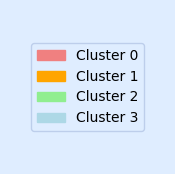

```python
# Defining the clusters along with their colors
clusters = ["Cluster 0", "Cluster 1", "Cluster 2", "Cluster 3"]
colors = ["lightcoral", "orange", "lightgreen", "lightblue"]

# Creating the custom legend entries
legend_patches = [Patch(color = colors[i], label = clusters[i]) for i in range(len(clusters))]

# Figure Size
fig, ax = plt.subplots(figsize = (2, 2))

# Shutting the axis
ax.axis("off")

# Adding Custom Color
fig.patch.set_facecolor('#dfedff')
ax.set_facecolor('#dfedff')

# Visualization - Legend
ax.legend(handles = legend_patches, loc = "center", fontsize = 10, title_fontsize = 12,
          facecolor = '#dfedff', edgecolor = '#b5c7e7')

# Showing
plt.show()
```

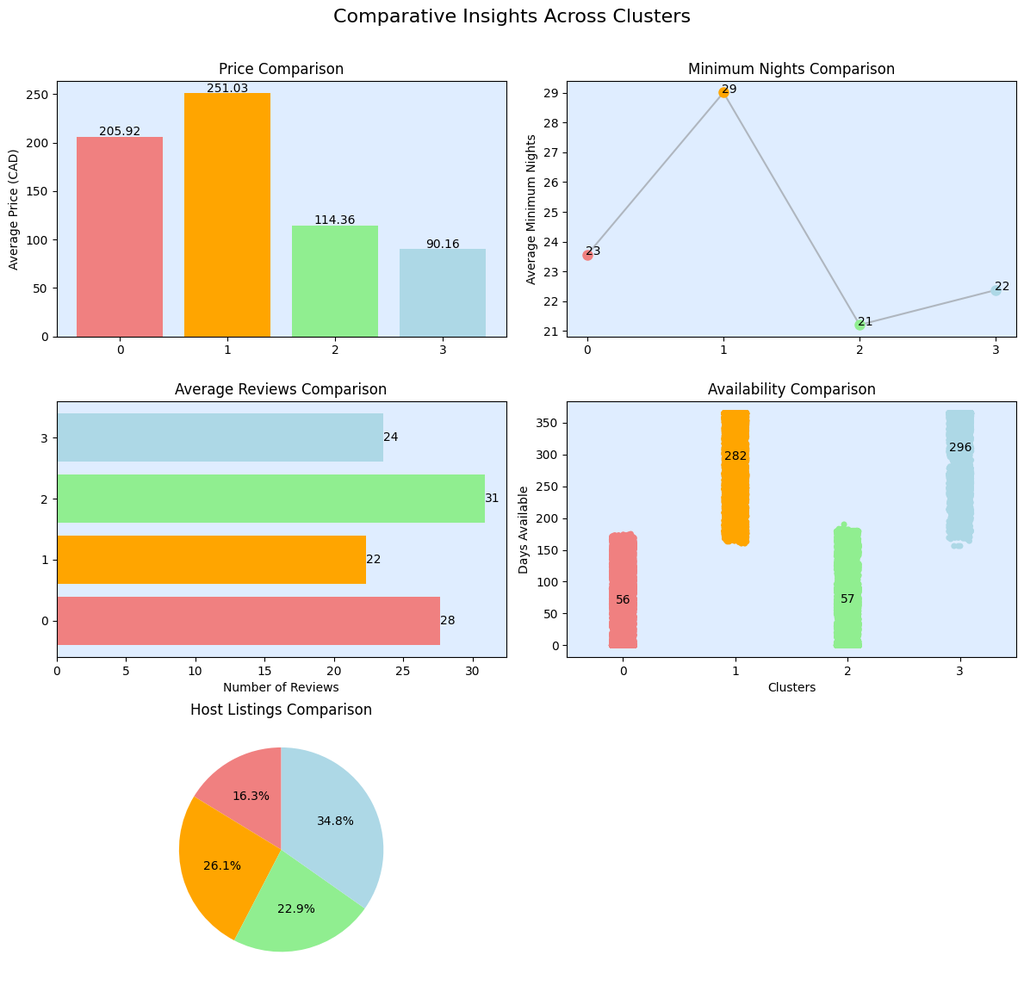

```python
# Grouping by 'PredictedCluster' and calculating the means
temp_data = vis_data.groupby("PredictedCluster").mean()

# Extracting insights for visualization
clusters = temp_data.index.astype(str)
prices_avg = temp_data["price"]
min_nights = temp_data["minimum_nights"]
reviews_avg = temp_data["number_of_reviews"]
availability_avg = temp_data["availability_365"]
host_listings_avg = temp_data["calculated_host_listings_count"]


# Creating subplots
fig, axs = plt.subplots(3, 2, figsize = (12, 12))

# Setting the background color for each subplot (axes)
for ax in axs.flat:
    ax.set_facecolor('#dfedff')

# Subplot title
fig.suptitle("Comparative Insights Across Clusters", fontsize = 16, y = 0.95)



# Visualization - BarGraph
axs[0, 0].bar(clusters, prices_avg, color = ['lightcoral', 'orange', 'lightgreen', 'lightblue'])

# Adding data values on bars
for i, v in enumerate(prices_avg):
    axs[0, 0].text(i, v + 5, f'{v:.2f}', ha = 'center', va = 'center', color = 'black', fontsize = 10)

# Labeling
axs[0, 0].set_title("Price Comparison")
axs[0, 0].set_ylabel("Average Price (CAD)")



# Visualization - Line Plot
axs[0, 1].plot(clusters, min_nights, color = 'gray', linestyle = '-', alpha = 0.5)

# Plotting each marker with different colors
for i, v in enumerate(min_nights):
    axs[0, 1].plot(clusters[i], v, marker = 'o', color = ['lightcoral', 'orange', 'lightgreen', 'lightblue'][i], markersize = 8)


# Adding data values on plot points
for i, v in enumerate(min_nights):
    axs[0, 1].text(i + 0.1, v - 0.1, f'{int(v)}', ha = 'right', va = 'bottom', color = 'black', fontsize = 10)

# Labeling
axs[0, 1].set_title("Minimum Nights Comparison")
axs[0, 1].set_ylabel("Average Minimum Nights")



# Visualization - Horizontal Bar Graph
axs[1, 0].barh(clusters, reviews_avg, color = ['lightcoral', 'orange', 'lightgreen', 'lightblue'])

# Adding data values on bars
for i, v in enumerate(reviews_avg):
    axs[1, 0].text(v, i, f'{v:.0f}', va = 'center', color = 'black', fontsize = 10)

# Labeling
axs[1, 0].set_title("Average Reviews Comparison")
axs[1, 0].set_xlabel("Number of Reviews")



# Visualization - Strip Plot for Availability
sns.stripplot(x = 'PredictedCluster', y = 'availability_365', data = vis_data, jitter = True,
              palette = ['lightcoral', 'orange', 'lightgreen', 'lightblue'], ax = axs[1, 1])

# Adding data values on scatter points
for i, v in enumerate(availability_avg):
    axs[1, 1].text(i, v + 5, f'{v:.0f}', ha = 'center', va = 'bottom', color = 'black', fontsize = 10)

# Labeling
axs[1, 1].set_title("Availability Comparison")
axs[1, 1].set_ylabel("Days Available")
axs[1, 1].set_xlabel("Clusters")



# Visualization - Pie Chart with bold text, custom color, and legend
axs[2, 0].pie(host_listings_avg, autopct = '%1.1f%%', startangle = 90,
              colors = ['lightcoral', 'orange', 'lightgreen', 'lightblue'],
              textprops = {'color': 'black'})

# Labeling
axs[2, 0].set_title("Host Listings Comparison")


# Hiding empty subplot
axs[2, 1].axis("off")

# Layout adjustment
plt.tight_layout()

# Subplots adjustment
plt.subplots_adjust(top = 0.88)

# Showing
plt.show()
```

# References

- [PyPI (Python Package Index)](https://pypi.org/)
- [Scikit-learn Documentation](https://scikit-learn.org/stable/)
- [NumPy Documentation](https://numpy.org/doc/stable/)
- [GeeksforGeeks](https://www.geeksforgeeks.org/)
- [Stack Overflow](https://stackoverflow.com/)
- [JavatPoint](https://www.javatpoint.com/)